# 506Assignment3

Author

Jiaqi Sun

Github repository: [Github](https://github.com/AlanGalaxy/506A3)

## Problem 1

It looks like stata code block cannot be folded. Some are quite long, sorry!

(a)

Reference: [STATA import sasxport](https://www.stata.com/manuals13/dimportsasxport.pdf). [STATA merge](https://www.stata.com/manuals/dmerge.pdf)

Import one data set and save it as “.dta” in order to let “merge” load the external .dta data set.

```stata
. import sasxport5 "C:/Users/sunjiaqi/Downloads/DEMO_D.XPT", clear

. save "C:/Users/sunjiaqi/Downloads/DEMO_D.dta", replace
file C:/Users/sunjiaqi/Downloads/DEMO_D.dta saved

. import sasxport5 "C:/Users/sunjiaqi/Downloads/VIX_D.XPT", clear

.
end of do-file
```

Merge the data sets using “seqn” 1 to 1.

```stata
. merge 1:1 seqn using "C:/Users/sunjiaqi/Downloads/DEMO_D.dta", keep(match)}

    Result                      Number of obs
    -----------------------------------------
    Not matched                             0
    Matched                             6,980  (_merge==3)
    -----------------------------------------

.
end of do-file
```

Get the number of rows, which is correctly equal to 6980.

```stata
. count
  6,980

.
end of do-file
```

(b)

Generate “age_bracket” column which indicates the age bracket one belongs to. Generate “distance_wear” column which indicates whether one wear glass/contact lenses.

```stata
. generate age_tens_digit = floor(ridageyr / 10)

. generate age_bracket = ""
(6,980 missing values generated)

. replace age_bracket = "10-19" if age_tens_digit == 1
variable age_bracket was str1 now str5
(2,207 real changes made)

. replace age_bracket = "20-29" if age_tens_digit == 2
(1,021 real changes made)

. replace age_bracket = "30-39" if age_tens_digit == 3
(818 real changes made)

. replace age_bracket = "40-49" if age_tens_digit == 4
(815 real changes made)

. replace age_bracket = "50-59" if age_tens_digit == 5
(631 real changes made)

. replace age_bracket = "60-69" if age_tens_digit == 6
(661 real changes made)

. replace age_bracket = "70-79" if age_tens_digit == 7
(469 real changes made)

. replace age_bracket = "80-89" if age_tens_digit == 8
(358 real changes made)

. generate distance_wear = ""
(6,980 missing values generated)

. replace distance_wear = "Yes" if viq220 == 1
variable distance_wear was str1 now str3
(2,765 real changes made)

. replace distance_wear = "No" if viq220 == 2
(3,780 real changes made)

. replace distance_wear = "DoNotKnow" if viq220 == 9
variable distance_wear was str3 now str9
(2 real changes made)

.
end of do-file
```

Build the table with proportion of respondents within each age bracket. The first row in each bracket is the number of respondents, and the second row is the proportion.

```stata
. tabulate age_bracket distance_wear, row

+----------------+
| Key            |
|----------------|
|   frequency    |
| row percentage |
+----------------+

age_bracke |          distance_wear
         t | DoNotKnow         No        Yes |     Total
-----------+---------------------------------+----------
     10-19 |         0      1,418        670 |     2,088
           |      0.00      67.91      32.09 |    100.00
-----------+---------------------------------+----------
     20-29 |         2        631        306 |       939
           |      0.21      67.20      32.59 |    100.00
-----------+---------------------------------+----------
     30-39 |         0        481        269 |       750
           |      0.00      64.13      35.87 |    100.00
-----------+---------------------------------+----------
     40-49 |         0        487        286 |       773
           |      0.00      63.00      37.00 |    100.00
-----------+---------------------------------+----------
     50-59 |         0        274        335 |       609
           |      0.00      44.99      55.01 |    100.00
-----------+---------------------------------+----------
     60-69 |         0        238        392 |       630
           |      0.00      37.78      62.22 |    100.00
-----------+---------------------------------+----------
     70-79 |         0        148        299 |       447
           |      0.00      33.11      66.89 |    100.00
-----------+---------------------------------+----------
     80-89 |         0        103        208 |       311
           |      0.00      33.12      66.88 |    100.00
-----------+---------------------------------+----------
     Total |         2      3,780      2,765 |     6,547
           |      0.03      57.74      42.23 |    100.00

.
end of do-file
```

(c)

Reference: [STATA Tables for multiple regression models](https://blog.stata.com/2021/09/02/customizable-tables-in-stata-17-part-6-tables-for-multiple-regression-models/), [STATA logistic](https://www.stata.com/manuals13/rlogistic.pdf), [STATA estat ic](https://www.stata.com/manuals13/restatic.pdf)

Remove the missing data and observations “Do not know”. Replace the value “2” with “0” to pass into logistic regression.

```stata
. keep if viq220 == 1 | viq220 == 2
(435 observations deleted)

. replace viq220 = 0 if viq220 == 2
(3,780 real changes made)

.
end of do-file
```

Clear and create a collection named “MyModels”.

```stata
. collect clear

. collect create MyModels
(current collection is MyModels)

.
end of do-file
```

Collect the data from logistic regression model 1 and the “AIC”.

```stata
. collect _r_b _r_se,                  ///
>         name(MyModels)                 ///
>         tag(model[(1)])                ///
>         : logistic viq220 c.ridageyr

Logistic regression                                     Number of obs =  6,545
                                                        LR chi2(1)    = 443.37
                                                        Prob > chi2   = 0.0000
Log likelihood = -4235.9433                             Pseudo R2     = 0.0497

------------------------------------------------------------------------------
      viq220 | Odds ratio   Std. err.      z    P>|z|     [95% conf. interval]
-------------+----------------------------------------------------------------
    ridageyr |    1.02498   .0012356    20.47   0.000     1.022561    1.027405
       _cons |    .283379   .0151461   -23.59   0.000     .2551952    .3146755
------------------------------------------------------------------------------
Note: _cons estimates baseline odds.

.
. collect AIC=r(S)[1,"AIC"],             ///
>         name(MyModels)                 ///
>         tag(model[(1)])                ///
>         : estat ic

Akaike's information criterion and Bayesian information criterion

-----------------------------------------------------------------------------
       Model |          N   ll(null)  ll(model)      df        AIC        BIC
-------------+---------------------------------------------------------------
           . |      6,545  -4457.627  -4235.943       2   8475.887    8489.46
-----------------------------------------------------------------------------
Note: BIC uses N = number of observations. See [R] IC note.

.
end of do-file
```

Collect the data from logistic regression model 2 and the “AIC”.

```stata
. collect _r_b _r_se,                    ///
>         name(MyModels)                 ///
>         tag(model[(2)])                ///
>         : logistic viq220 c.ridageyr i.ridreth1 i.riagendr

Logistic regression                                     Number of obs =  6,545
                                                        LR chi2(6)    = 641.49
                                                        Prob > chi2   = 0.0000
Log likelihood = -4136.8805                             Pseudo R2     = 0.0720

------------------------------------------------------------------------------
      viq220 | Odds ratio   Std. err.      z    P>|z|     [95% conf. interval]
-------------+----------------------------------------------------------------
    ridageyr |   1.022831   .0012912    17.88   0.000     1.020303    1.025365
             |
    ridreth1 |
          2  |   1.169203    .192081     0.95   0.341     .8473273    1.613349
          3  |   1.952149   .1366952     9.55   0.000     1.701803    2.239322
          4  |    1.29936   .0995052     3.42   0.001     1.118264    1.509783
          5  |   1.917442   .2596352     4.81   0.000     1.470495    2.500236
             |
  2.riagendr |    1.65217   .0875831     9.47   0.000     1.489127    1.833064
       _cons |   .1593479   .0124169   -23.57   0.000     .1367784    .1856414
------------------------------------------------------------------------------
Note: _cons estimates baseline odds.

.
. collect AIC=r(S)[1,"AIC"],             ///
>         name(MyModels)                 ///
>         tag(model[(2)])                ///
>         : estat ic

Akaike's information criterion and Bayesian information criterion

-----------------------------------------------------------------------------
       Model |          N   ll(null)  ll(model)      df        AIC        BIC
-------------+---------------------------------------------------------------
           . |      6,545  -4457.627   -4136.88       7   8287.761   8335.266
-----------------------------------------------------------------------------
Note: BIC uses N = number of observations. See [R] IC note.

.
end of do-file
```

Remove missing data in “Poverty income ratio”.

```stata
. keep if indfmpir >= 0 & indfmpir <= 5
(298 observations deleted)

.
end of do-file
```

Collect the data from logistic regression model 3 and the “AIC”.

```stata
. collect _r_b _r_se,                         ///
>         name(MyModels)                      ///
>         tag(model[(3)])                     ///
>         : logistic viq220 c.ridageyr i.ridreth1 i.riagendr c.indfmpir

Logistic regression                                     Number of obs =  6,247
                                                        LR chi2(7)    = 625.30
                                                        Prob > chi2   = 0.0000
Log likelihood = -3946.9041                             Pseudo R2     = 0.0734

------------------------------------------------------------------------------
      viq220 | Odds ratio   Std. err.      z    P>|z|     [95% conf. interval]
-------------+----------------------------------------------------------------
    ridageyr |   1.022436    .001324    17.14   0.000     1.019845    1.025035
             |
    ridreth1 |
          2  |   1.123021   .1889653     0.69   0.490     .8075333    1.561764
          3  |   1.651244   .1240886     6.67   0.000     1.425098    1.913277
          4  |   1.230456   .0974736     2.62   0.009     1.053503     1.43713
          5  |   1.703572   .2387583     3.80   0.000     1.294384    2.242114
             |
  2.riagendr |   1.675767   .0910025     9.51   0.000      1.50657    1.863967
    indfmpir |   1.120301   .0198376     6.42   0.000     1.082087    1.159865
       _cons |   .1331659   .0116903   -22.97   0.000     .1121161    .1581678
------------------------------------------------------------------------------
Note: _cons estimates baseline odds.

.
. collect AIC=r(S)[1,"AIC"],                  ///
>         name(MyModels)                      ///
>         tag(model[(3)])                     ///
>         : estat ic

Akaike's information criterion and Bayesian information criterion

-----------------------------------------------------------------------------
       Model |          N   ll(null)  ll(model)      df        AIC        BIC
-------------+---------------------------------------------------------------
           . |      6,247  -4259.553  -3946.904       8   7909.808   7963.727
-----------------------------------------------------------------------------
Note: BIC uses N = number of observations. See [R] IC note.

.
end of do-file
```

Modify the styles.

```stata
. collect style showbase off

. collect style row stack, spacer delimiter(" x ")

. collect style cell, nformat(%5.2f)

. collect style cell result[N AIC], nformat(%8.0f)

. collect style cell result[_r_se], sformat("(%s)")

. collect style header result[AIC], level(label)

.
. collect style cell cell_type[item column-header], halign(center)

. collect style column, extraspace(1)

.
end of do-file
```

Preview the table.

```stata
. collect preview

-----------------------------------------------------------------
                                      |    (1)      (2)      (3)
--------------------------------------+--------------------------
Age at Screening Adjudicated - Recode |
  Coefficient                         |   1.02     1.02     1.02
  Std. error                          |  (0.00)   (0.00)   (0.00)
                                      |
Race/Ethnicity - Recode=2             |
  Coefficient                         |            1.17     1.12
  Std. error                          |           (0.19)   (0.19)
Race/Ethnicity - Recode=3             |
  Coefficient                         |            1.95     1.65
  Std. error                          |           (0.14)   (0.12)
Race/Ethnicity - Recode=4             |
  Coefficient                         |            1.30     1.23
  Std. error                          |           (0.10)   (0.10)
Race/Ethnicity - Recode=5             |
  Coefficient                         |            1.92     1.70
  Std. error                          |           (0.26)   (0.24)
                                      |
Gender=2                              |
  Coefficient                         |            1.65     1.68
  Std. error                          |           (0.09)   (0.09)
                                      |
Family PIR                            |
  Coefficient                         |                     1.12
  Std. error                          |                    (0.02)
                                      |
Intercept                             |
  Coefficient                         |   0.28     0.16     0.13
  Std. error                          |  (0.02)   (0.01)   (0.01)
                                      |
Number of observations                |   6545     6545     6247
                                      |
Pseudo R-squared                      |   0.05     0.07     0.07
                                      |
AIC                                   |   8476     8288     7910
-----------------------------------------------------------------

.
end of do-file
```

Save the table to a PDF file.

```stata
. putpdf clear

. putpdf begin

. putpdf paragraph, font("Calibri Light",26) halign(center)

. putpdf text ("Respondent Who Wear Glass/Contact Lenses for Distance Vision")

.
. collect style putpdf, width(60%) indent(1 in)          ///
>         title("Table: Logistic Regression Models for Wearing of Glass/Contact Lenses for Di
> stance Vision")                         ///
>         note("Note: Odds ratio (standard error)")

. putpdf collect
(collection MyModels posted to putpdf)

. putpdf save "C:/Users/sunjiaqi/Downloads/MyTable.pdf", replace
successfully created "C:/Users/sunjiaqi/Downloads/MyTable.pdf"

.
end of do-file
```

The PDF file looks like the image below, and is available in Github.

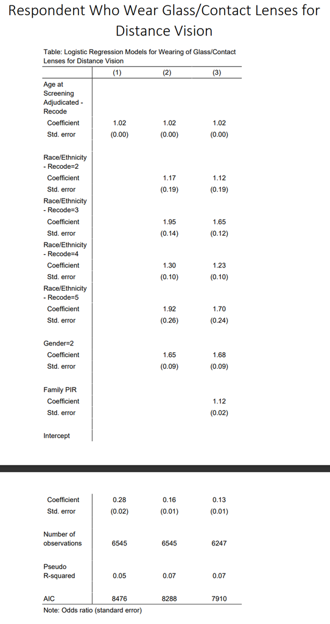

(d)

The odds of female over male is 1.675767. The coefficient is 0.5162712, with z-statistic 9.51. The p-value is 0.000 < 0.05. The difference is significant. The proportion of wearers of glasses/contact lenses for distance vision differs between men and women.

```stata
. logistic viq220 c.ridageyr i.ridreth1 i.riagendr c.indfmpir

Logistic regression                                     Number of obs =  6,247
                                                        LR chi2(7)    = 625.30
                                                        Prob > chi2   = 0.0000
Log likelihood = -3946.9041                             Pseudo R2     = 0.0734

------------------------------------------------------------------------------
      viq220 | Odds ratio   Std. err.      z    P>|z|     [95% conf. interval]
-------------+----------------------------------------------------------------
    ridageyr |   1.022436    .001324    17.14   0.000     1.019845    1.025035
             |
    ridreth1 |
          2  |   1.123021   .1889653     0.69   0.490     .8075333    1.561764
          3  |   1.651244   .1240886     6.67   0.000     1.425098    1.913277
          4  |   1.230456   .0974736     2.62   0.009     1.053503     1.43713
          5  |   1.703572   .2387583     3.80   0.000     1.294384    2.242114
             |
  2.riagendr |   1.675767   .0910025     9.51   0.000      1.50657    1.863967
    indfmpir |   1.120301   .0198376     6.42   0.000     1.082087    1.159865
       _cons |   .1331659   .0116903   -22.97   0.000     .1121161    .1581678
------------------------------------------------------------------------------
Note: _cons estimates baseline odds.

.
end of do-file
```

From logit we can directly get the coefficients.

```stata
. logit viq220 c.ridageyr i.ridreth1 i.riagendr c.indfmpir

Iteration 0:  Log likelihood = -4259.5533
Iteration 1:  Log likelihood = -3948.3256
Iteration 2:  Log likelihood = -3946.9043
Iteration 3:  Log likelihood = -3946.9041

Logistic regression                                     Number of obs =  6,247
                                                        LR chi2(7)    = 625.30
                                                        Prob > chi2   = 0.0000
Log likelihood = -3946.9041                             Pseudo R2     = 0.0734

------------------------------------------------------------------------------
      viq220 | Coefficient  Std. err.      z    P>|z|     [95% conf. interval]
-------------+----------------------------------------------------------------
    ridageyr |   .0221883   .0012949    17.14   0.000     .0196504    .0247263
             |
    ridreth1 |
          2  |   .1160225   .1682651     0.69   0.490     -.213771    .4458161
          3  |   .5015289   .0751486     6.67   0.000     .3542404    .6488174
          4  |   .2073846   .0792175     2.62   0.009     .0521211     .362648
          5  |   .5327271   .1401516     3.80   0.000     .2580349    .8074192
             |
  2.riagendr |   .5162712    .054305     9.51   0.000     .4098355     .622707
    indfmpir |   .1135978   .0177073     6.42   0.000      .078892    .1483035
       _cons |   -2.01616   .0877879   -22.97   0.000    -2.188221   -1.844099
------------------------------------------------------------------------------

.
end of do-file
```

## Problem 2

(a)

Load the data.

```r
# install.packages("DBI")
# install.packages("RSQLite")
library(DBI)
# Build connection
sakila <- dbConnect(RSQLite::SQLite(), "D:/Code/R/sakila_master.db")
sakila
```

```
<SQLiteConnection>
  Path: D:\Code\R\sakila_master.db
  Extensions: TRUE
```

Join “film” and “language” to get the data.

```r
query <- "
  SELECT language.name AS 'language', COUNT(*) AS 'count'
    FROM film
         JOIN language ON film.language_id = language.language_id
   WHERE language.name != 'English'
   GROUP BY language.name
   ORDER BY COUNT(*) DESC
   LIMIT 1;
"
result <- dbGetQuery(sakila, query)
result
```

```
[1] language count
<0 rows> (or 0-length row.names)
```

There is no films with other language.

(b)

Select proper table from the SQL, and then do the rest in R.

```r
# SQL & R
# Get the tables
film <- dbGetQuery(sakila, "SELECT * FROM film")
film_category <- dbGetQuery(sakila, "SELECT * FROM film_category")
category <- dbGetQuery(sakila, "SELECT * FROM category")
# Merge them
T1 <- merge(film, film_category, by = "film_id")
T2 <- merge(T1, category, by = "category_id")

table <- table(T2$name)
table[which.max(table)]
```

```
Sports
    74
```

Sports is the most common genre with 74 films.

Get the result use single SQL query.

```r
# SQL Only
query <- "
  SELECT film_id_category_name.name AS 'genre', COUNT(*) AS 'count'
    FROM (SELECT film_id, name
            FROM category
                 JOIN film_category ON category.category_id =
                                       film_category.category_id
         ) AS film_id_category_name
         JOIN film ON film_id_category_name.film_id = film.film_id
   GROUP BY name
   ORDER BY COUNT(*) DESC
   LIMIT 1;
"
result <- dbGetQuery(sakila, query)
result
```

```
   genre count
1 Sports    74
```

We get the same result.

(c)

Select proper table from the SQL, and then do the rest in R.

```r
# SQL & R
# Get the tables
customer <- dbGetQuery(sakila, "SELECT * FROM customer")
address <- dbGetQuery(sakila, "SELECT * FROM address")
city <- dbGetQuery(sakila, "SELECT * FROM city")
country <- dbGetQuery(sakila, "SELECT * FROM country")
# Merge them
T1 <- merge(customer, address, by = "address_id", suffixes = c("cust", "add"),
            no.dups = FALSE)
T2 <- merge(T1, city, by = "city_id", no.dups = FALSE)
T3 <- merge(T2, country, by = "country_id", no.dups = FALSE)

table <- table(T3$country)
table[table == 9]
```

```
United Kingdom
             9
```

United Kingdom has exactly 9 customers.

Get the result use single SQL query.

```r
# SQL Only
query <- "
  SELECT country.country AS 'country', COUNT(*) AS 'count'
    FROM customer
         JOIN address ON customer.address_id = address.address_id
         JOIN city ON address.city_id = city.city_id
         JOIN country ON city.country_id = country.country_id
   GROUP BY country.country
  HAVING COUNT(*) = 9;
"
result <- dbGetQuery(sakila, query)
result
```

```
         country count
1 United Kingdom     9
```

We get the same result.

Disconnect the SQLite.

```r
dbDisconnect(sakila)
```

## Problem 3

(a)

Load the data.

```r
us <- read.csv("D:/Code/R/us-500.csv", header = TRUE)
dim(us)
```

```
[1] 500  12
```

Get the email column. The regular expression matches string with “@” + any number of character +“.net”, and “.net” must be the end.

```r
email <- us$email

net_TLD <- email[grep("@.*\\.net$", email)]
length(net_TLD) / nrow(us)
```

```
[1] 0.14
```

The proportion of email with “.net” TLD is 0.14.

(b)

Replace all the character “@” (include) with empty. “\\.[^.]*$” will match characters from the last “.” to the end of the string. “[^[:alnum:]]” will match any non alphanumeric character.

This will find non alphanumeric alphanumeric characters in the customizable parts, except the “@” and “.” in TLD.

```r
# Delete @
email <- sub("@", "", email)
# Delete the LTD part
local_email <- sub("\\.[^.]*$", "", email)

non_alphanum_email <- email[grep("[^[:alnum:]]", local_email)]
length(non_alphanum_email) / nrow(us)
```

```
[1] 0.506
```

The proportion of email addresses have at least one non alphanumeric character is 0.506

(c)

Get the two phone number columns. Get the first three digits, which is the are code.

```r
phone <- c(us$phone1, us$phone2)
area_code <- substr(phone,1, 3)
t <- table(area_code)
sort(t, decreasing = TRUE)[1]
```

```
973
 36
```

The most common area code is “973”. There are 36 phone number in that area code.

(d)

Get the address column. Then get the address with number at the end. Extract the last few number, which is the apartment number. Draw the histogram of the log results.

“(//d+)$” will find at least one digit at the end.

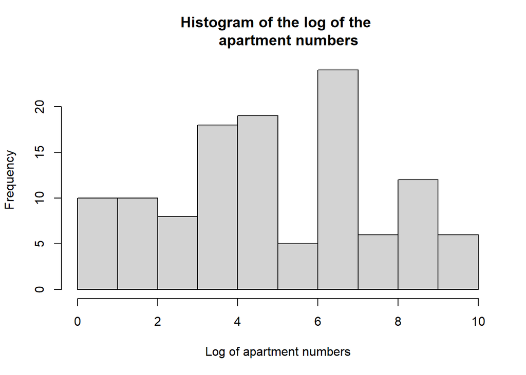

```r
address <- us$address
apartment_num_address <- address[grep("(\\d+)$", address)]
library(stringr)
apartment_num <- str_extract(apartment_num_address, "(\\d+)$")
hist(log(as.numeric(apartment_num)), main = "Histogram of the log of the
     apartment numbers", xlab = "Log of apartment numbers")
```

(e)

Get the first digit of the apartment number. Draw the histogram and the simulated points of Benford’s Law.

“^(\\d)” will find the first digit.

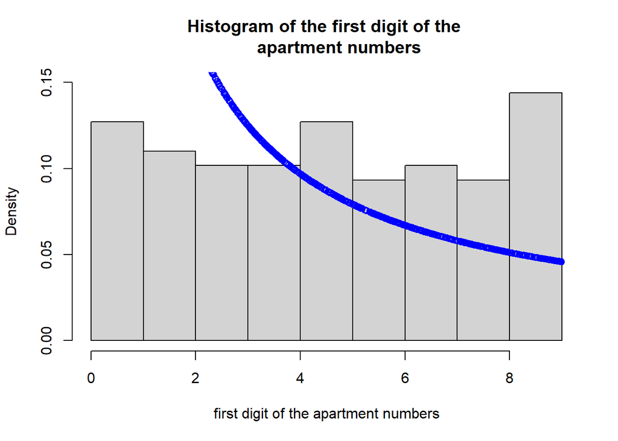

```r
leading_digit <- str_extract(apartment_num, "^(\\d)")
hist(as.numeric(leading_digit), main = "Histogram of the first digit of the
     apartment numbers", xlab = "first digit of the apartment numbers",
     breaks = 0:9, freq = FALSE, ylim = c(0, 0.15))
# Generate distribution follows Benford's Law
x <- runif(1000, min = 0, max = 9)
Benford <- log10(1/x+1)
points(y = Benford, x = x, col = "blue", lwd = 1)
```

The apartment number **does not** pass as real data. All the number from 1 to 9 seem equal likely be the first digit.

(f)

“^(\\d+)” will find the digit(s) at the beginning. “(\\d)$” will find the last digit.

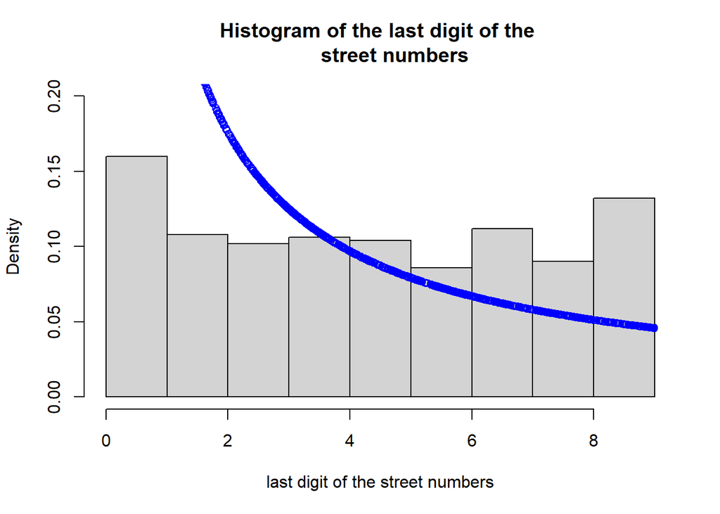

```r
street_num <- str_extract(address, "^(\\d+)")
last_digit <- str_extract(street_num, "(\\d)$")
hist(as.numeric(last_digit), main = "Histogram of the last digit of the
     street numbers", xlab = "last digit of the street numbers",
     breaks = 0:9, freq = FALSE, ylim = c(0, 0.2))
points(y = Benford, x = x, col = "blue", lwd = 1)
```

The street number **does not** pass as real data. All the number from 1 to 9 seem equal likely be the last digit.